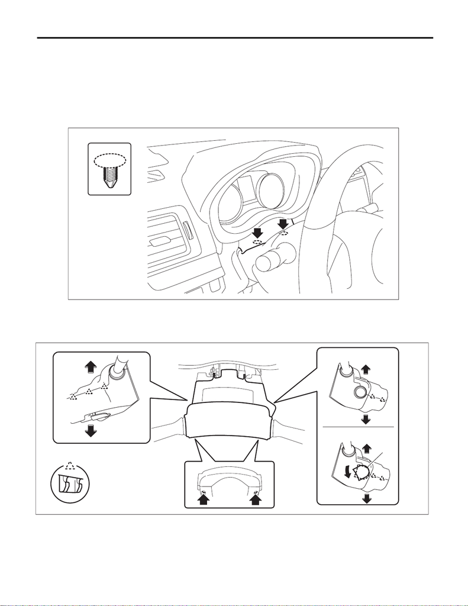

WW-8

Combination Switch (Wiper)

WIPER AND WASHER SYSTEMS

4. Combination Switch (Wiper)

A: REMOVAL

1) Disconnect the ground cable from battery. <Ref. to NT-5, BATTERY, NOTE, Note.>

NOTE:

For models other than STI model, disconnect the ground terminal from battery sensor.

2) Remove the cover assembly - column.

(1) Remove the clips, and remove the cover - column.

(2) Remove the screws by turning the steering wheel to right and left.

(3) Remove the cap - key cylinder (a). (Model with keyless access)

(4) Release the claw, and remove the cover assembly - column UPR and the cover assembly - column

LWR.

A Model without keyless access B Model with keyless access

PS-01710

PS-01384

A

B

(a)

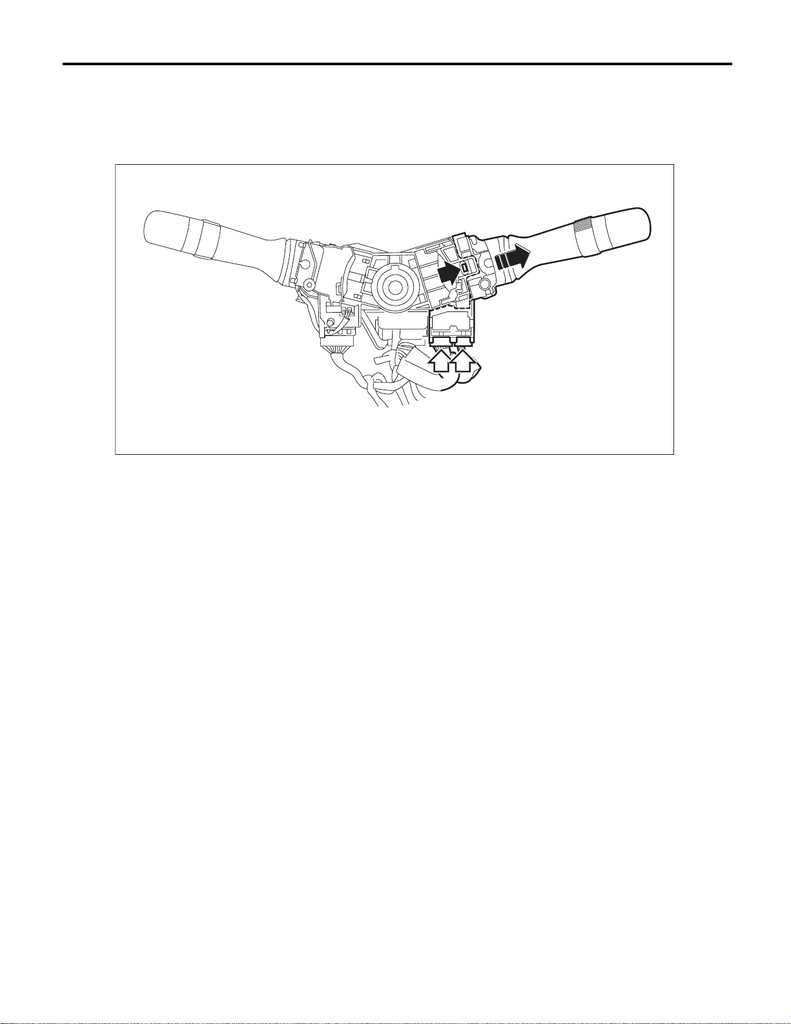

WW-9

Combination Switch (Wiper)

WIPER AND WASHER SYSTEMS

3) Remove the switch assembly - combination wiper select.

(1) Disconnect the connector.

(2) Release the claws, and pull out the switch assembly - combination wiper select.

CAUTION:

Do not press the claws with excessive force. They may be damaged.

B: INSTALLATION

1) Install the switch assembly - combination wiper select.

2) Install the cover assembly - column.

3) Connect the battery ground terminal. <Ref. to NT-5, BATTERY, NOTE, Note.>

NOTE:

For models other than STI model, connect the ground terminal to battery sensor.

WW-01165

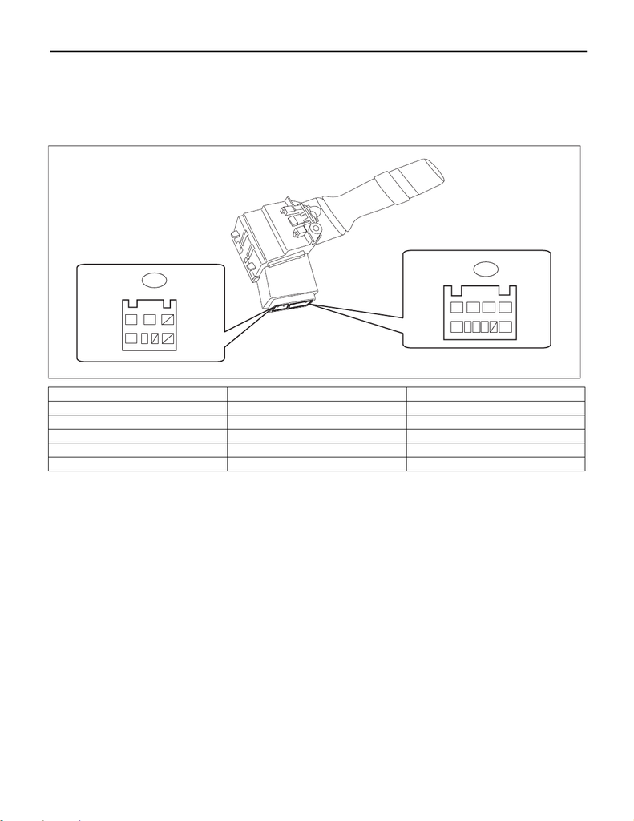

WW-10

Combination Switch (Wiper)

WIPER AND WASHER SYSTEMS

C: INSPECTION

1. INSPECTION OF SWITCH UNIT

1) Operate the switches to check the continuity between terminals.

Preparation tool:

Circuit tester

2) Replace the switch if the inspection result is not within the standard value.

3) Install the switch assembly - combination wiper select. <Ref. to WW-9, INSTALLATION, Combination

Switch (Wiper).>

Switch position Terminal No. Standard

OFF A1 and A3 Less than 1 Ω

INT A1 and A3 Less than 1 Ω

LO A2 and A3 Less than 1 Ω

HI A2 and A4 Less than 1 Ω

Washer ON B2 and B3 Less than 1 Ω

WW-00815

1

23

6

23

5

10

7

4

B558

B70

B:

A:

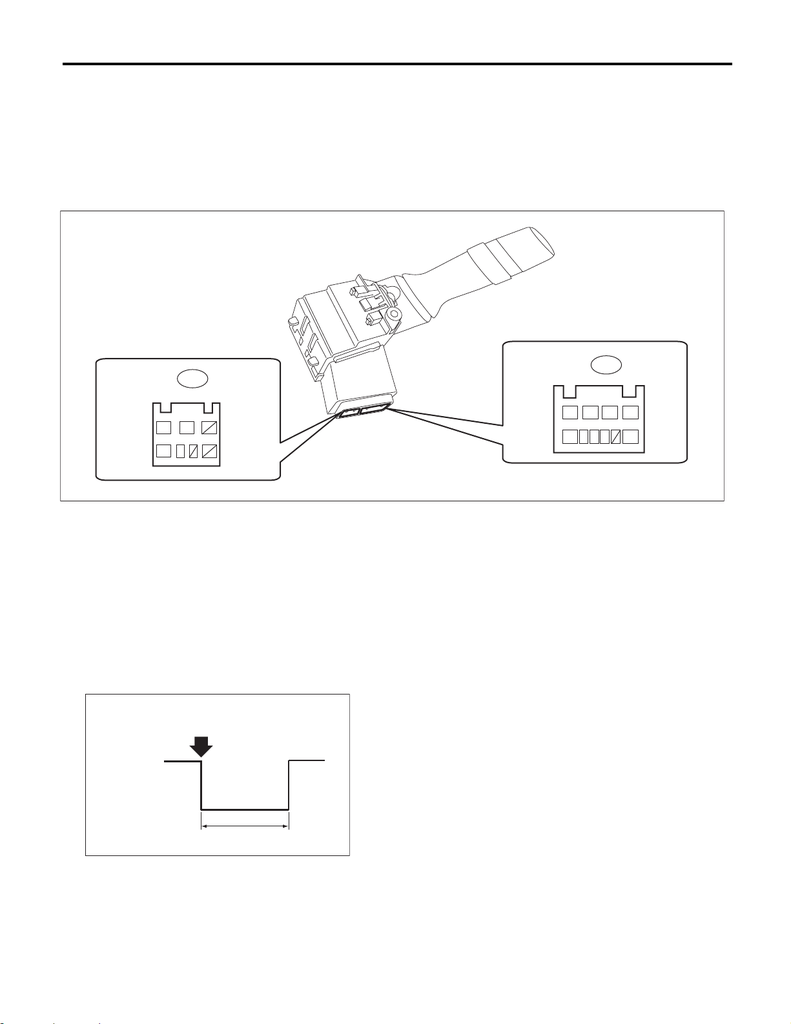

WW-11

Combination Switch (Wiper)

WIPER AND WASHER SYSTEMS

2. FRONT WIPER

1) Check with Subaru Select Monitor

(1) Check the input signal when the switch assembly - combination wiper select is turned to LO or HI, us-

ing the current data display.

(2) Does the input signal change corresponding to the switch operation?

• Yes → Finish the diagnosis.

• No → Check the harness.

2) Check the intermittent operation (inspection of the wiper switch alone).

(2) Connect the battery to connector. (Terminal No. A2 (+), terminal No. B2 & A3 (–))

(3) Turn the switch assembly - combination wiper select to INT.

(4) Connect the battery (+) to the terminal No. A2 for 5 seconds.

(5) Connect the battery (–) to the terminal No. B2, and check the voltage between terminals No. A2 and

No. A3 during intermittent operation.

if the operation is not as specified.

Intermittent stationary time

MIN: Approx. 2 seconds

MAX: Approx. 16 seconds

WW-00815

1

23

6

23

5

10

7

4

B558

B70

B:

A:

WW-00393

(A)

S

12 V

0 V

(A): Connect the battery (–) to the terminal No. B2.

S: Intermittent downtime (sec.)